# Final Project Notebook

DS 5001 Text as Data

# Metadata

- Full Name: Marissa Burton
- Userid: marissa-data
- GitHub Repo URL: https://github.com/marissa-data/ds5001-project
- UVA Box URL: https://virginia.box.com/s/9omqn29vmjf7oyddrvcm2e0vb4hgyjus

# Overview

The goal of the final project is for you to create a **digital analytical edition** of a corpus using the tools, practices, and perspectives you’ve learning in this course. You will select a corpus that has already been digitized and transcribed, parse that into an F-compliant set of tables, and then generate and visualize the results of a series of fitted models. You will also draw some tentative conclusions regarding the linguistic, cultural, psychological, or historical features represented by your corpus. The point of the exercise is to have you work with a corpus through the entire pipeline from ingestion to interpretation.

Specifically, you will acquire a collection of long-form texts and perform the following operations:

- **Convert** the collection from their source formats (F0) into a set of tables that conform to the Standard Text Analytic Data Model (F2).
- **Annotate** these tables with statistical and linguistic features using NLP libraries such as NLTK (F3).
- **Produce** a vector representation of the corpus to generate TFIDF values to add to the TOKEN (aka CORPUS) and VOCAB tables (F4).
- **Model** the annotated and vectorized model with tables and features derived from the application of unsupervised methods, including PCA, LDA, and word2vec (F5).
- **Explore** your results using statistical and visual methods.
- **Present** conclusions about patterns observed in the corpus by means of these operations.

When you are finished, you will make the results of your work available in GitHub (for code) and UVA Box (for data). You will submit to Gradescope (via Canvas) a PDF version of a Jupyter notebook that contains the information listed below.

# Some Details

- Please fill out your answers in each task below by editing the markdown cell.
- Replace text that asks you to insert something with the thing, i.e. replace `(INSERT IMAGE HERE)` with an image element, e.g. `![](image.png)`.
- For URLs, just paste the raw URL directly into the text area. Don't worry about providing link labels using `[label](link)`.
- Please do not alter the structure of the document or cell, i.e. the bulleted lists.
- You may add explanatory paragraphs below the bulleted lists.
- Please name your tables as they are named in each task below.
- Tasks are indicated by headers with point values in parentheses.

# Raw Data

## Source Description (1)

Provide a brief description of your source material, including its provenance and content. Tell us where you found it and what kind of content it contains.

For this project, I am analyzing gothic literature from the late 18th century (1790s) to mid-20th century (1950s). Each text file collected contains manuscripts (plus additional metainformation) of each gothic novel. 11 out of the 12 text files were downloaded from the Project Gutenberg website, which serves as an online library for classic texts. 1 of the text files was downloaded from the Faded Page website, another classic literature online library.

## Source Features (1)

Add values for the following items. (Do this for all following bulleted lists.)

- Source URL: https://docs.google.com/document/d/1t4vSmm_VFKwJ5tSDDpuyiCZMmlyj1vAS1f4V1t4Ryfk/edit?usp=sharing
- UVA Box URL: https://virginia.box.com/s/yfzugdfpdsttfs68szvfgu7rn5z9bv40
- Number of raw documents: 12
- Total size of raw documents (e.g. in MB): 5.3 MB
- File format(s), e.g. XML, plaintext, etc.: plaintext

## Source Document Structure (1)

Provide a brief description of the internal structure of each document. That, describe the typical elements found in document and their relation to each other. For example, a corpus of letters might be described as having a date, an addressee, a salutation, a set of content paragraphs, and closing. If they are various structures, state that.

Every novel in this project at least contains a title, author(s), an opening, and a closing. Other common features include a table of contents with chapter titles, chapter numbers, additonal information about the novel/author at the beginning or end of the text file, and unique characters used to represent page/content breaks.

# Parsed and Annotated Data

Parse the raw data into the three core tables of your addition: the `LIB`, `CORPUS`, and `VOCAB` tables.

These tables will be stored as CSV files with header rows.

You may consider using `|` as a delimitter.

Provide the following information for each.

The source documents the corpus comprises. These may be books, plays, newspaper articles, abstracts, blog posts, etc.

Note that these are *not* documents in the sense used to describe a bag-of-words representation of a text, e.g. chapter.

## VOCAB (2)

The unique word types (terms) in the corpus.

- UVA Box URL: https://virginia.box.com/s/22ol8xo4tqahwa534630hzlmaq2eeo02
- GitHub URL for notebook used to create: https://github.com/marissa-data/ds5001-project/blob/main/derived_tables.ipynb
- Delimitter: CSV
- Number of observations: 21,227
- Columns (as delimitted names, including `n`, `p`', `i`, `dfidf`, `porter_stem`, `max_pos` and `max_pos_group`, `stop`): 'n', 'n_chars', 'p', 'i', 'max_pos', 'max_pos_group', 'stop', 'stem_porter', 'df', 'idf', 'dfidf', 'tfidf_mean', 'ngram_length'
- Note: Your VOCAB may contain ngrams. If so, add a feature for `ngram_length`.
- List the top 20 significant words in the corpus by DFIDF.

'looks', 'blue', 'repeated', 'road', 'gentle', 'clear', 'sounds', 'peace', 'sitting', 'object', 'chair', 'heaven', 'covered', 'learn', 'learned', 'meant', 'grave', 'greater', 'dare', 'spirit'

# Derived Tables

## BOW (3)

A bag-of-words representation of the CORPUS.

- UVA Box URL: https://virginia.box.com/s/yv6u2gcmeeyb2r6w6w685yhr9gbqibqz
- GitHub URL for notebook used to create: https://github.com/marissa-data/ds5001-project/blob/main/derived_tables.ipynb
- Delimitter: CSV
- Bag (expressed in terms of OHCO levels): 'CHAPS'
- Number of observations: 149,416
- Columns (as delimitted names, including `n`, `tfidf`): 'n', 'tfidf_mean'

## DTM (3)

A represenation of the BOW as a sparse count matrix.

- UVA Box URL: https://virginia.box.com/s/0tm6rp0mbkddertoobxe6gljsckudl94
- UVA Box URL of BOW used to generate (if applicable): https://virginia.box.com/s/yv6u2gcmeeyb2r6w6w685yhr9gbqibqz
- GitHub URL for notebook used to create: https://github.com/marissa-data/ds5001-project/blob/main/derived_tables.ipynb
- Delimitter: CSV
- Bag (expressed in terms of OHCO levels): 'CHAPS'

## TFIDF (3)

A Document-Term matrix with TFIDF values.

- UVA Box URL: https://virginia.box.com/s/z83jgt4g226awj80wahtlmx5y796bfep
- UVA Box URL of DTM or BOW used to create: https://virginia.box.com/s/0tm6rp0mbkddertoobxe6gljsckudl94
- GitHub URL for notebook used to create: https://github.com/marissa-data/ds5001-project/blob/main/derived_tables.ipynb
- Delimitter: CSV
- Description of TFIDF formula ($\LaTeX$ OK): $TFIDF(t,d)=log_2(1+f(t,d))×log_2(N/DF(t))$

## Reduced and Normalized TFIDF_L2 (3)

A Document-Term matrix with L2 normalized TFIDF values.

- UVA Box URL: https://virginia.box.com/s/72lg4wuh5lzf0d5ztmy1b79ghz55vigw
- UVA Box URL of source TFIDF table: https://virginia.box.com/s/z83jgt4g226awj80wahtlmx5y796bfep
- GitHub URL for notebook used to create: https://github.com/marissa-data/ds5001-project/blob/main/derived_tables.ipynb
- Delimitter: CSV
- Number of features (i.e. significant words): 20,714
- Principle of significant word selection: Terms below a significance threshold of 0.125 were excluded.

# Models

## PCA Components (4)

- UVA Box URL: https://virginia.box.com/s/ppffzgvnmqxw5e28w4bdahxctj3uxxaf
- UVA Box URL of the source TFIDF_L2 table: https://virginia.box.com/s/72lg4wuh5lzf0d5ztmy1b79ghz55vigw
- GitHub URL for notebook used to create: https://github.com/marissa-data/ds5001-project/blob/main/pca.ipynb
- Delimitter: CSV
- Number of components: 5
- Library used to generate: sklearn.preprocessing (normalize), sklearn.decomposition (PCA, TruncatedSVD)
- Top 5 positive terms for first component: 'herbert', 'paw', 't', 'eleanor', 'don'
- Top 5 negative terms for second component: 'herbert', 'paw', 'sergeantmajor', 'talisman', 'monkey'

## PCA DCM (4)

The document-component matrix generated.

- UVA Box URL: https://virginia.box.com/s/mx753rcv6848bpwhjzcfxb0d7k53ikrn
- GitHub URL for notebook used to create: https://github.com/marissa-data/ds5001-project/blob/main/pca.ipynb
- Delimitter: CSV

## PCA Loadings (4)

The component-term matrix generated.

- UVA Box URL: https://virginia.box.com/s/ppffzgvnmqxw5e28w4bdahxctj3uxxaf
- GitHub URL for notebook used to create: https://github.com/marissa-data/ds5001-project/blob/main/pca.ipynb
- Delimitter: CSV

## PCA Visualization 1 (4)

Include a scatterplot of documents in the space created by the first two components.

Color the points based on a metadata feature associated with the documents.

Also include a scatterplot of the loadings for the same two components. (This does not need a feature mapped onto color.)

[figure not shown]

Briefly describe the nature of the polarity you see in the first component:

PC 1 differentiates between high and classical/romantic gothic texts and victorian and modern gothic texts, suggesting a separation between earlier and later gothic works. Terms that are more aligned with each era (romantic and nature focused for earlier texts, psychology and modern realism focused for later texts) confirm this polarity in the LOADINGS visualization.

## PCA Visualization 2 (4)

Include a scatterplot of documents in the space created by the second two components.

Color the points based on a metadata feature associated with the documents.

Also include a scatterplot of the loadings for the same two components. (This does not need a feature mapped onto color.)

[figure not shown]

Briefly describe the nature of the polarity you see in the second component:

Like PC 1, PC 2 also separates high gothic and classical/romantic gothic text from victorian and modern gothic. The more positive terms for PC2 describe externalized horror, while the more negative terms tend to descriibe internalized/psychological horror. This suggests that while earlier texts show societal fear through external objects, later texts turn this fear inwards, aligning with more modern scientific and psychological advancement.

## LDA TOPIC (4)

- UVA Box URL: https://virginia.box.com/s/bej9ib5s8kdmnyvywn6maqqa44jefux9
- UVA Box URL of count matrix used to create: https://virginia.box.com/s/pwfk0sr35xomngz048ol0lr2kgrio2mw
- GitHub URL for notebook used to create: https://github.com/marissa-data/ds5001-project/blob/main/lda.ipynb
- Delimitter: CSV
- Libary used to compute: sklearn.feature_extraction.text (CountVectorizer), sklearn.decomposition (LDA, NMF)
- A description of any filtering, e.g. POS (Nouns and Verbs only): Filtered for nouns
- Number of components: 20
- Any other parameters used: None
- Top 5 words and best-guess labels for topic five topics by mean document weight:
  - T19 door room night came mr (bedtime)
  - T06 house doctor door mrs hill (domestic settings)
  - T12 shall van helsing lucy come (Dracula)
  - T07 christine raoul erik voice persian (Phantom of the Opera)
  - T14 father life moment god felt (familial connection)

## LDA THETA (4)

- UVA Box URL: https://virginia.box.com/s/0fmh68p6229yjaubynqgwppt62qjzug8
- GitHub URL for notebook used to create: https://github.com/marissa-data/ds5001-project/blob/main/lda.ipynb
- Delimitter: CSV

## LDA PHI (4)

- UVA Box URL: https://virginia.box.com/s/i713xh6c4bche3wqg9yqqd62u3mz4sq9
- GitHub URL for notebook used to create: https://github.com/marissa-data/ds5001-project/blob/main/lda.ipynb
- Delimitter: CSV

## LDA + PCA Visualization (4)

Apply PCA to the THETA table and plot the topics in the space opened by the first two components.

Size the points based on the mean document weight of each topic (using the THETA table).

Color the points basd on a metadata feature from the LIB table.

Provide a brief interpretation of what you see.

[figure not shown]

This plot showcases how topics with the same dominant eras of classical/romantic and high gothic have a lot more topic overlap in comparison to the other eras (more so in high gothic). In both victorian and modern gothic literature eras, there exists a strong outlier, suggesting topics across these eras are more diverse.

## Sentiment VOCAB_SENT (4)

Sentiment values associated with a subset of the VOCAB from a curated sentiment lexicon.

- UVA Box URL: https://virginia.box.com/s/xeu6s5lpgq3vedeqs926gtdvdvij9eb3
- UVA Box URL for source lexicon: https://virginia.box.com/s/znv26g9t7une4taec4rxnpezx4bj2f9g
- GitHub URL for notebook used to create: https://github.com/marissa-data/ds5001-project/blob/main/sentiment.ipynb
- Delimitter: CSV

## Sentiment BOW_SENT (4)

Sentiment values from VOCAB_SENT mapped onto BOW.

- UVA Box URL: https://virginia.box.com/s/as3a5gnb1qfdfu8iy764l4bumscltksn
- GitHub URL for notebook used to create: https://github.com/marissa-data/ds5001-project/blob/main/sentiment.ipynb
- Delimitter: CSV

## Sentiment DOC_SENT (4)

Computed sentiment per bag computed from BOW_SENT.

- UVA Box URL: https://virginia.box.com/s/6n8h2bguuwv19i5eg8auvckpnm2fyahr
- GitHub URL for notebook used to create: https://github.com/marissa-data/ds5001-project/blob/main/sentiment.ipynb
- Delimitter: CSV
- Document bag expressed in terms of OHCO levels: era

## Sentiment Plot (4)

Plot sentiment over some metric space, such as time.

If you don't have a metric metadata features, plot sentiment over a feature of your choice.

You may use a bar chart or a line graph.

[figure not shown]

Here, I used the GI lexicon to group features into different operationalizations of fear, with breakdown representing failure and social disorder, affective representing negativity in general, conflict representing hostility and aggression, and structural representing all facets of societal power.

## VOCAB_W2V (4)

A table of word2vec features associated with terms in the VOCAB table.

- UVA Box URL: https://virginia.box.com/s/b23o88sezp9pc2g833oem0lnhnsc0mxe
- GitHub URL for notebook used to create: https://github.com/marissa-data/ds5001-project/blob/main/word2vec.ipynb
- Delimitter: CSV
- Document bag expressed in terms of OHCO levels: sentences
- Number of features generated: 200
- The library used to generate the embeddings: gensim

## Word2vec tSNE Plot (4)

Plot word embedding featues in two-dimensions using t-SNE.

Describe a cluster in the plot that captures your attention.

[figure not shown]

The cluster that includes words like strength, spirit, emotion, imagination, and curiosity (captured on the right side of the image above) represents the internal aspects of characters, most likely represented in depth in later works (aligning with the PCA findings). Interestingly, words like order, influence, and servant are semantically related to the former cluster, suggesting these words all capture different aspects of societal fear.

# Riffs

Provde at least three visualizations that combine the preceding model data in interesting ways.

These should provide insight into how features in the LIB table are related.

The nature of this relationship is left open to you -- it may be correlation, or mutual information, or something less well defined.

In doing so, consider the following visualization types:

- Hierarchical cluster diagrams
- Heatmaps
- Scatter plots
- KDE plots
- Dispersion plots
- t-SNE plots
- etc.

## Riff 1 (5)

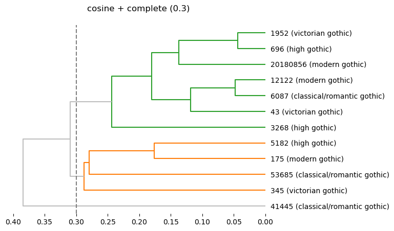

I used a complete cosine similarity in order to assess the relationship between different gothic novels. My significance threshold is very low (0.3) because these novels are more closely related than anticipated; yet, we can still draw some conclusions from this dendrogram. While the green cluster shows more similarity between novels (includes novels across all gothic eras), the orange cluster forms a separate branch, indicating an increased difference across texts. This indicates that genre/style similarity is not strictly determined by era.

## Riff 2 (5)

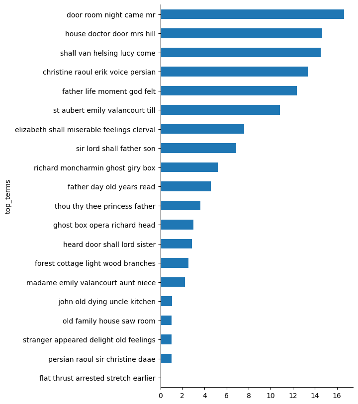

Using LDA topic modeling techniques, I was able to generate this image that shows the highest weighted terms in each of the 20 topics I created. While some topics tend to explicitly define what novel or era they describe based on the highest topic-word probabilities (e.g., the terms "christine raoul erik voice persian" indicate that this topic includes vocabulary from the Phantom of the Opera), other topics tend to represent things like locations, familial relationships, and actions.

## Riff 3 (5)

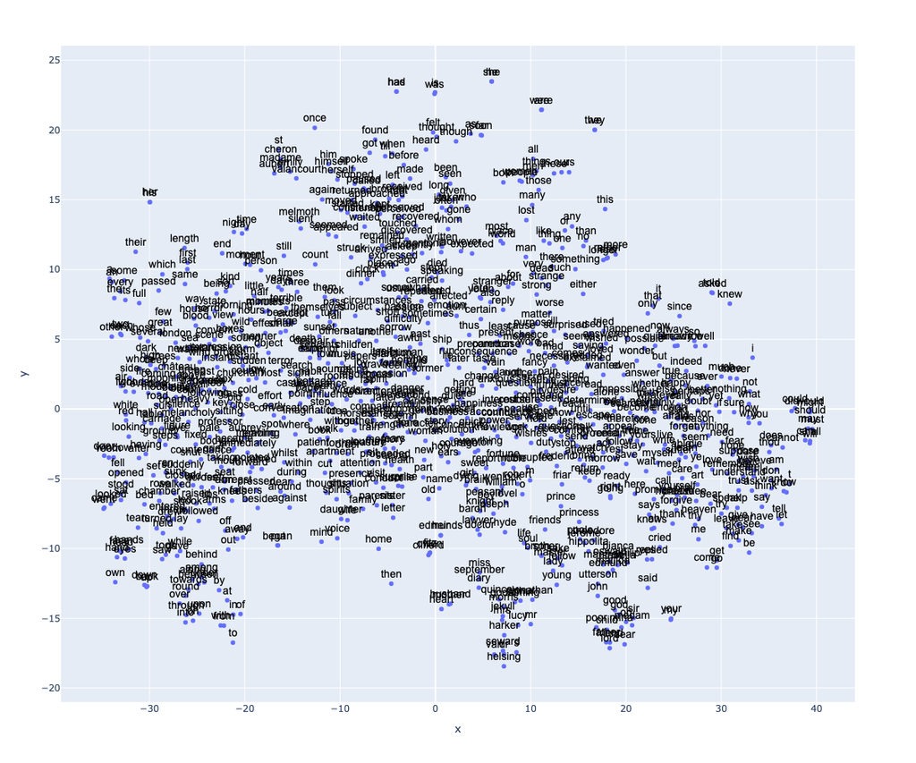

[figure not shown]

For this riff, I generated a new tSNE plot using CHAPS as a bag instead of SENTS. This plot seems to be picking up on more broad themes across the novels as opposed to the random noise that might show up with SENTS as the bag. I've picked out a cluster in particular that describes body parts; this is proof that the tSNE method is correctly grouping similar terms.

# Interpretation (4)

Describe something interesting about your corpus that you discovered during the process of completing this assignment.

At a minumum, use 250 words, but you may use more. You may also add images if you'd like.

Through completing this assignment, I found that the novels we chose to represent each gothic era of literature (high gothic, romantic/classical gothic, victorian gothic, and modern gothic) do not deterministically predict novel-specific features. This is to be expected, since the novels were a mixture of long and short forms, were all written by different authors with different writing styles, and all tackled diverse themes within the genre of gothic literature. However, through both PCA and sentiment analysis, I discovered that life-threatening fear was much more prevalent in earlier texts (high and romantic/classical gothic eras). The abundance of historical conflicts/wars in the late 1790s to the early 1800s heavily influenced gothic literature authors to encorporate themes of violence and death (often represented through monsters) into their stories (through both realistic fiction and sci-fi/fantasy/horror novels). In comparison, novels written in the late 19th century and beyond (victorian and modern gothic eras) captured the shift to internalized fears, which was largely driven by the increased understanding of mental and emotional health and less conflicts related to physical violence; often these novels focus on personal relationships/experiences as opposed to the widespread horror expressed in earlier texts. Specifically in the LDA and PCA visualization, you can see how diverse these topics within internalized fear are; authors included in this corpus creatively expressed differing aspects of these societial fears through their unique stories, making novel topics less similar statistically. Additionally, since the GI lexicon did not explicitly define many themes related to this more nuanced type of fear, it appears as if fear is not as prevalent of a theme in these later texts. However, both PCA visualizations provide assurance that victorian and modern gothic texts are semantically related, but it is unclear if this is because of similar themes of internalized fear, or because of confounding variables like writing styles and prevalant vocabulary in the later time periods (or hopefully a mixture of both). Overall, it was a fun project to complete and exploring these famous novels through text analysis techniques offered an increased insight into both intended and unintended thematic choices made by each author, without having to read the novels myself.